[figure not shown]

# Advanced Regression Assignment

**Author:** Anish Mahapatra

*Machine Learning II > Module 3*

# Problem Statement

US-based housing company Suprise Housing would like to enter the Australian Market. The company uses data analytics to purchase houses at a price below their actual values and flip them on at a higher price. For the same purpose, the company has collected a data set from the sale of houses in Australia.

The company is looking at prospective properties to buy to enter the market. A regression model using regularisation is to be built in order to predict the actual value of the prospective properties and decide whether to invest in them or not.

The company wants to know the following:

- Which variables are significant in predicting the price of a house, and
- How well those variables describe the price of a house.

We are also to determine the optimal value of lambda for ridge and lasso regression.

### Goals of case Study:

The price of the house is to be modelled with the available independent variables. The model will be used by the management to understand how the prices vary with the variables. Based on this input, the strategy of the firm can be manipulated to yield high returns. The model will also enable the management to understand the pricing dynamics of the new market

### Evaluation Rubric:

- Data Quality Checks - missing value imputation, removing duplicate data, data redundancies
- Data Quality Issues mentioned and clearly explained in comments
- Dummy variables are created & New Metrics are derived, wherever applicable
- Model Parameters are tuned using correct principles (Both Technical and Business)
- Correct Variable Selection Techniques are used, reasonable number of models are iterated over
- Model evaluation using correct principles and appropriate evaluation metrics are chosen
- Model is interpreted and explained correctly

### Data Cleaning

- Handle actual missing values
- Find percentage of missing values
- Drop columns that have a high percentage of missing values
- Drop columns that are highly skewed
- Impute data wherever required
- Check if target variable (Sales price) is normally distributed or not. If it is not normally distributed, perform transformation to make it normally distributed
- Create dummy variables from categorical columns
- Convert year column to find age by using Age = max(YearColumn) - year in the row
- Scale the data

### Modeling

- Perform Ridge and Lasso Regression
- Perform Hyperparameter tuning to get optimal lambda
- Describe the model

#### Importing Required packages and Loading the data

```python
# Importing the required variables

import matplotlib.pyplot as plt
import seaborn as sns
import sklearn
import pandas as pd
import numpy as np
%matplotlib inline
import warnings
```

```python
# Removing the minimum display columns to 500
pd.set_option('display.max_columns', 500)
pd.set_option('display.max_rows', 500)

# Ignore Warnings
warnings.filterwarnings("ignore")
```

```python
# Reading the csv file as a pandas dataframe
housingData = pd.read_csv('Data/train.csv')
```

```python
# Viewing the head of the dataset
housingData.head()
```

|  | Id | MSSubClass | MSZoning | LotFrontage | LotArea | Street | Alley | LotShape | LandContour | Utilities | LotConfig | LandSlope | Neighborhood | Condition1 | Condition2 | BldgType | HouseStyle | OverallQual | OverallCond | YearBuilt | YearRemodAdd | RoofStyle | RoofMatl | Exterior1st | Exterior2nd | MasVnrType | MasVnrArea | ExterQual | ExterCond | … |
| --- | --- | --- | --- | --- | --- | --- | --- | --- | --- | --- | --- | --- | --- | --- | --- | --- | --- | --- | --- | --- | --- | --- | --- | --- | --- | --- | --- | --- | --- | --- |
| 0 | 1 | 60 | RL | 65.0 | 8450 | Pave | NaN | Reg | Lvl | AllPub | Inside | Gtl | CollgCr | Norm | Norm | 1Fam | 2Story | 7 | 5 | 2003 | 2003 | Gable | CompShg | VinylSd | VinylSd | BrkFace | 196.0 | Gd | TA | … |
| 1 | 2 | 20 | RL | 80.0 | 9600 | Pave | NaN | Reg | Lvl | AllPub | FR2 | Gtl | Veenker | Feedr | Norm | 1Fam | 1Story | 6 | 8 | 1976 | 1976 | Gable | CompShg | MetalSd | MetalSd | None | 0.0 | TA | TA | … |
| 2 | 3 | 60 | RL | 68.0 | 11250 | Pave | NaN | IR1 | Lvl | AllPub | Inside | Gtl | CollgCr | Norm | Norm | 1Fam | 2Story | 7 | 5 | 2001 | 2002 | Gable | CompShg | VinylSd | VinylSd | BrkFace | 162.0 | Gd | TA | … |
| 3 | 4 | 70 | RL | 60.0 | 9550 | Pave | NaN | IR1 | Lvl | AllPub | Corner | Gtl | Crawfor | Norm | Norm | 1Fam | 2Story | 7 | 5 | 1915 | 1970 | Gable | CompShg | Wd Sdng | Wd Shng | None | 0.0 | TA | TA | … |
| 4 | 5 | 60 | RL | 84.0 | 14260 | Pave | NaN | IR1 | Lvl | AllPub | FR2 | Gtl | NoRidge | Norm | Norm | 1Fam | 2Story | 8 | 5 | 2000 | 2000 | Gable | CompShg | VinylSd | VinylSd | BrkFace | 350.0 | Gd | TA | … |

#### Sense Check of the data

```python
# Viewing the shape fo the dataset
housingData.shape
```

```
(1460, 81)
```

```python
type(housingData)
```

```
pandas.core.frame.DataFrame
```

```python
# Viewing information regarding the dataset
housingData.info()
```

```
<class 'pandas.core.frame.DataFrame'>
RangeIndex: 1460 entries, 0 to 1459
Data columns (total 81 columns):
Id               1460 non-null int64
MSSubClass       1460 non-null int64
MSZoning         1460 non-null object
LotFrontage      1201 non-null float64
LotArea          1460 non-null int64
Street           1460 non-null object
Alley            91 non-null object
LotShape         1460 non-null object
LandContour      1460 non-null object
Utilities        1460 non-null object
LotConfig        1460 non-null object
LandSlope        1460 non-null object
Neighborhood     1460 non-null object
Condition1       1460 non-null object
Condition2       1460 non-null object
BldgType         1460 non-null object
HouseStyle       1460 non-null object
OverallQual      1460 non-null int64
OverallCond      1460 non-null int64
YearBuilt        1460 non-null int64
YearRemodAdd     1460 non-null int64
RoofStyle        1460 non-null object
RoofMatl         1460 non-null object
Exterior1st      1460 non-null object
Exterior2nd      1460 non-null object
MasVnrType       1452 non-null object
MasVnrArea       1452 non-null float64
ExterQual        1460 non-null object
ExterCond        1460 non-null object
Foundation       1460 non-null object
BsmtQual         1423 non-null object
BsmtCond         1423 non-null object
BsmtExposure     1422 non-null object
BsmtFinType1     1423 non-null object
BsmtFinSF1       1460 non-null int64
BsmtFinType2     1422 non-null object
BsmtFinSF2       1460 non-null int64
```

[output cut: 31 more lines]

```
EnclosedPorch    1460 non-null int64
3SsnPorch        1460 non-null int64
ScreenPorch      1460 non-null int64
PoolArea         1460 non-null int64
PoolQC           7 non-null object
Fence            281 non-null object
MiscFeature      54 non-null object
MiscVal          1460 non-null int64
MoSold           1460 non-null int64
YrSold           1460 non-null int64
SaleType         1460 non-null object
SaleCondition    1460 non-null object
SalePrice        1460 non-null int64
dtypes: float64(3), int64(35), object(43)
memory usage: 924.0+ KB
```

# Exploratory Data Analysis

We shall now proceed to perform EDA on the dataset

## Missing Value Analysis

```python
df = housingData.copy(deep=True)
```

```python
# Calculating the percent of missing values in the dataframe
percentMissing = (df.isnull().sum() / len(df)) * 100

# Making a dataframe with the missing values % and columns into a dataframe (on account of large number of rows)
missingValuesDf = pd.DataFrame({'Column Name': df.columns,
                                 'Percent of data missing': percentMissing})

# Viewing the % of missing data
missingValuesDf
```

|  | Column Name | Percent of data missing |
| --- | --- | --- |
| Id | Id | 0.000000 |
| MSSubClass | MSSubClass | 0.000000 |
| MSZoning | MSZoning | 0.000000 |
| LotFrontage | LotFrontage | 17.739726 |
| LotArea | LotArea | 0.000000 |
| Street | Street | 0.000000 |
| Alley | Alley | 93.767123 |
| LotShape | LotShape | 0.000000 |
| LandContour | LandContour | 0.000000 |
| Utilities | Utilities | 0.000000 |
| LotConfig | LotConfig | 0.000000 |
| LandSlope | LandSlope | 0.000000 |
| Neighborhood | Neighborhood | 0.000000 |
| Condition1 | Condition1 | 0.000000 |
| Condition2 | Condition2 | 0.000000 |
| BldgType | BldgType | 0.000000 |
| HouseStyle | HouseStyle | 0.000000 |
| OverallQual | OverallQual | 0.000000 |
| OverallCond | OverallCond | 0.000000 |
| YearBuilt | YearBuilt | 0.000000 |
| YearRemodAdd | YearRemodAdd | 0.000000 |
| RoofStyle | RoofStyle | 0.000000 |
| RoofMatl | RoofMatl | 0.000000 |
| Exterior1st | Exterior1st | 0.000000 |
| Exterior2nd | Exterior2nd | 0.000000 |
| MasVnrType | MasVnrType | 0.547945 |
| MasVnrArea | MasVnrArea | 0.547945 |
| ExterQual | ExterQual | 0.000000 |
| ExterCond | ExterCond | 0.000000 |
| Foundation | Foundation | 0.000000 |

[output cut: 51 more lines]

We realize that a lot of the columns have 'NA' values. There are two kinds of missing values here:

1. Actual missing values in the form of NA - indicative of missing entries
2. Meaningful NA values that are indicative of a missing feature

#### Type I: Actual Missing Values

- LotFrontage: Linear feet of street connected to property
- MasVnrType: Masonry veneer type - This attribute has type None to indicate that the feature is missing. Hence, NA is indicative of atual missing value
- MasVnrArea: Masonry veneer area in square feet
- Electrical: Electrical system - NA indicative of actual missing data

#### Type II: Indicative of the feature missing on the property

- Alley: Type of alley access to property
- BsmtQual: Evaluates the height of the basement
- BsmtCond: Evaluates the general condition of the basement
- BsmtExposure: Refers to walkout or garden level walls
- BsmtFinType1: Rating of basement finished area
- BsmtFinType2: Rating of basement finished area (if multiple types)
- FireplaceQu: Fireplace quality
- GarageType: Garage location
- GarageYrBlt: Year garage was built
- GarageFinish: Interior finish of the garage
- GarageQual: Garage quality
- GarageCond: Garage condition
- PoolQC: Pool quality
- Fence: Fence quality
- MiscFeature: Miscellaneous feature not covered in other categories

#### Handling Missing values

```python
# Replacing 'NA' values with missing values for the columns that have actual missing values

df['LotFrontage'] = df['LotFrontage'].replace('NA','')
df['MasVnrType'] = df['MasVnrType'].replace('NA','')
df['MasVnrArea'] = df['MasVnrArea'].replace('NA','')
df['Electrical'] = df['Electrical'].replace('NA','')
df['GarageYrBlt'] = df['GarageYrBlt'].replace('NA','')
```

```python
# Replacing the 'NA' values with what they are indicative of instead of missing values
df['Alley'].fillna('NoAlley', inplace = True)
df['BsmtQual'].fillna('NoBasement', inplace = True)
df['BsmtCond'].fillna('NoBasement', inplace = True)
df['BsmtExposure'].fillna('NoBasement', inplace = True)
df['BsmtFinType1'].fillna('NoBasement', inplace = True)
df['BsmtFinType2'].fillna('NoBasement', inplace = True)
df['FireplaceQu'].fillna('NoFireplace', inplace = True)
df['GarageType'].fillna('NoGarage', inplace = True)
df['GarageFinish'].fillna('NoGarage', inplace = True)
df['GarageQual'].fillna('NoGarage', inplace = True)
df['GarageCond'].fillna('NoGarage', inplace = True)
df['PoolQC'].fillna('NoPool', inplace = True)
df['Fence'].fillna('NoFence', inplace = True)
df['MiscFeature'].fillna('NoMiscFeature', inplace = True)
```

```python
# Calculating the percent of missing values in the dataframe
percentMissing = (df.isnull().sum() / len(df)) * 100

# Making a dataframe with the missing values % and columns into a dataframe (on account of large number of rows)
missingValuesDf = pd.DataFrame({'Column Name': df.columns,
                                 'Percent of data missing': percentMissing})

# Viewing the % of missing data
missingValuesDf
```

|  | Column Name | Percent of data missing |
| --- | --- | --- |
| Id | Id | 0.000000 |
| MSSubClass | MSSubClass | 0.000000 |
| MSZoning | MSZoning | 0.000000 |
| LotFrontage | LotFrontage | 17.739726 |
| LotArea | LotArea | 0.000000 |
| Street | Street | 0.000000 |
| Alley | Alley | 0.000000 |
| LotShape | LotShape | 0.000000 |
| LandContour | LandContour | 0.000000 |
| Utilities | Utilities | 0.000000 |
| LotConfig | LotConfig | 0.000000 |
| LandSlope | LandSlope | 0.000000 |
| Neighborhood | Neighborhood | 0.000000 |
| Condition1 | Condition1 | 0.000000 |
| Condition2 | Condition2 | 0.000000 |
| BldgType | BldgType | 0.000000 |
| HouseStyle | HouseStyle | 0.000000 |
| OverallQual | OverallQual | 0.000000 |
| OverallCond | OverallCond | 0.000000 |
| YearBuilt | YearBuilt | 0.000000 |
| YearRemodAdd | YearRemodAdd | 0.000000 |
| RoofStyle | RoofStyle | 0.000000 |
| RoofMatl | RoofMatl | 0.000000 |
| Exterior1st | Exterior1st | 0.000000 |
| Exterior2nd | Exterior2nd | 0.000000 |
| MasVnrType | MasVnrType | 0.547945 |
| MasVnrArea | MasVnrArea | 0.547945 |
| ExterQual | ExterQual | 0.000000 |
| ExterCond | ExterCond | 0.000000 |
| Foundation | Foundation | 0.000000 |

[output cut: 51 more lines]

**Removal of columns that have missing values:**

We **do not remove** any columns on the basis of missing values as the % of missing values are of an acceptable range (<20%)

% of columns removed: 0%

```python
# Viewing the data
df.head()
```

|  | Id | MSSubClass | MSZoning | LotFrontage | LotArea | Street | Alley | LotShape | LandContour | Utilities | LotConfig | LandSlope | Neighborhood | Condition1 | Condition2 | BldgType | HouseStyle | OverallQual | OverallCond | YearBuilt | YearRemodAdd | RoofStyle | RoofMatl | Exterior1st | Exterior2nd | MasVnrType | MasVnrArea | ExterQual | ExterCond | … |
| --- | --- | --- | --- | --- | --- | --- | --- | --- | --- | --- | --- | --- | --- | --- | --- | --- | --- | --- | --- | --- | --- | --- | --- | --- | --- | --- | --- | --- | --- | --- |
| 0 | 1 | 60 | RL | 65.0 | 8450 | Pave | NoAlley | Reg | Lvl | AllPub | Inside | Gtl | CollgCr | Norm | Norm | 1Fam | 2Story | 7 | 5 | 2003 | 2003 | Gable | CompShg | VinylSd | VinylSd | BrkFace | 196.0 | Gd | TA | … |
| 1 | 2 | 20 | RL | 80.0 | 9600 | Pave | NoAlley | Reg | Lvl | AllPub | FR2 | Gtl | Veenker | Feedr | Norm | 1Fam | 1Story | 6 | 8 | 1976 | 1976 | Gable | CompShg | MetalSd | MetalSd | None | 0.0 | TA | TA | … |
| 2 | 3 | 60 | RL | 68.0 | 11250 | Pave | NoAlley | IR1 | Lvl | AllPub | Inside | Gtl | CollgCr | Norm | Norm | 1Fam | 2Story | 7 | 5 | 2001 | 2002 | Gable | CompShg | VinylSd | VinylSd | BrkFace | 162.0 | Gd | TA | … |
| 3 | 4 | 70 | RL | 60.0 | 9550 | Pave | NoAlley | IR1 | Lvl | AllPub | Corner | Gtl | Crawfor | Norm | Norm | 1Fam | 2Story | 7 | 5 | 1915 | 1970 | Gable | CompShg | Wd Sdng | Wd Shng | None | 0.0 | TA | TA | … |
| 4 | 5 | 60 | RL | 84.0 | 14260 | Pave | NoAlley | IR1 | Lvl | AllPub | FR2 | Gtl | NoRidge | Norm | Norm | 1Fam | 2Story | 8 | 5 | 2000 | 2000 | Gable | CompShg | VinylSd | VinylSd | BrkFace | 350.0 | Gd | TA | … |

#### Mapping and dummy one-hot encoding

Column that has binary mapping:

- CentralAir

Rest of the categorical columns would require dummy one-hot encoding.

#### Binary Encoding

```python
# List of variables to map
variableList =  ['CentralAir']

# Defining the map function
def binary_map(x):
    return x.map({'Y': 1, 'N': 0})

# Applying the function to the housing list
df[variableList] = df[variableList].apply(binary_map)
```

#### Dummy one-hot encoding

```python
# Selecting only the categorical columns to perform numerical analysis on
categorical = ['object']
df_obj = df.select_dtypes(include=categorical)

# Converting the column names into a list
listOfFeaturesToPerformDummyOneHotEncodingOn = list(df_obj.columns)

# Viewing the list of categorical columns
listOfFeaturesToPerformDummyOneHotEncodingOn
```

```
['MSZoning',
 'Street',
 'Alley',
 'LotShape',
 'LandContour',
 'Utilities',
 'LotConfig',
 'LandSlope',
 'Neighborhood',
 'Condition1',
 'Condition2',
 'BldgType',
 'HouseStyle',
 'RoofStyle',
 'RoofMatl',
 'Exterior1st',
 'Exterior2nd',
 'MasVnrType',
 'ExterQual',
 'ExterCond',
 'Foundation',
 'BsmtQual',
 'BsmtCond',
 'BsmtExposure',
 'BsmtFinType1',
 'BsmtFinType2',
 'Heating',
 'HeatingQC',
 'Electrical',
 'KitchenQual',
 'Functional',
 'FireplaceQu',
 'GarageType',
 'GarageFinish',
 'GarageQual',
 'GarageCond',
 'PavedDrive',
 'PoolQC',
 'Fence',
 'MiscFeature',
 'SaleType',
 'SaleCondition']
```

```python
# Creating a dummy variable for some of the categorical variables and dropping the first one
dummyVariables = pd.get_dummies(df[listOfFeaturesToPerformDummyOneHotEncodingOn], drop_first = True)

# Adding the results to the master dataframe
df_dummy = pd.concat([df, dummyVariables], axis=1)
```

```python
# Viewing the shape of the data
df_dummy.shape
```

```
(1460, 303)
```

```python
df_dummy.head()
```

|  | Id | MSSubClass | MSZoning | LotFrontage | LotArea | Street | Alley | LotShape | LandContour | Utilities | LotConfig | LandSlope | Neighborhood | Condition1 | Condition2 | BldgType | HouseStyle | OverallQual | OverallCond | YearBuilt | YearRemodAdd | RoofStyle | RoofMatl | Exterior1st | Exterior2nd | MasVnrType | MasVnrArea | ExterQual | ExterCond | … |
| --- | --- | --- | --- | --- | --- | --- | --- | --- | --- | --- | --- | --- | --- | --- | --- | --- | --- | --- | --- | --- | --- | --- | --- | --- | --- | --- | --- | --- | --- | --- |
| 0 | 1 | 60 | RL | 65.0 | 8450 | Pave | NoAlley | Reg | Lvl | AllPub | Inside | Gtl | CollgCr | Norm | Norm | 1Fam | 2Story | 7 | 5 | 2003 | 2003 | Gable | CompShg | VinylSd | VinylSd | BrkFace | 196.0 | Gd | TA | … |
| 1 | 2 | 20 | RL | 80.0 | 9600 | Pave | NoAlley | Reg | Lvl | AllPub | FR2 | Gtl | Veenker | Feedr | Norm | 1Fam | 1Story | 6 | 8 | 1976 | 1976 | Gable | CompShg | MetalSd | MetalSd | None | 0.0 | TA | TA | … |
| 2 | 3 | 60 | RL | 68.0 | 11250 | Pave | NoAlley | IR1 | Lvl | AllPub | Inside | Gtl | CollgCr | Norm | Norm | 1Fam | 2Story | 7 | 5 | 2001 | 2002 | Gable | CompShg | VinylSd | VinylSd | BrkFace | 162.0 | Gd | TA | … |
| 3 | 4 | 70 | RL | 60.0 | 9550 | Pave | NoAlley | IR1 | Lvl | AllPub | Corner | Gtl | Crawfor | Norm | Norm | 1Fam | 2Story | 7 | 5 | 1915 | 1970 | Gable | CompShg | Wd Sdng | Wd Shng | None | 0.0 | TA | TA | … |
| 4 | 5 | 60 | RL | 84.0 | 14260 | Pave | NoAlley | IR1 | Lvl | AllPub | FR2 | Gtl | NoRidge | Norm | Norm | 1Fam | 2Story | 8 | 5 | 2000 | 2000 | Gable | CompShg | VinylSd | VinylSd | BrkFace | 350.0 | Gd | TA | … |

```python
# Dropping the categorical variables as dummy variables have been created
df_dummy = df_dummy.drop(['MSZoning', 'Street', 'Alley', 'LotShape', 'LandContour', 'Utilities', 'LotConfig', \
                          'LandSlope', 'Neighborhood', 'Condition1', 'Condition2', 'BldgType', 'HouseStyle', \
                          'RoofStyle', 'RoofMatl', 'Exterior1st', 'Exterior2nd', 'MasVnrType', 'ExterQual', 'ExterCond', \
                          'Foundation', 'BsmtQual', 'BsmtCond', 'BsmtExposure', 'BsmtFinType1', 'BsmtFinType2', 'Heating', \
                          'HeatingQC', 'Electrical', 'KitchenQual', 'Functional', 'FireplaceQu', 'GarageType',\
                          'GarageFinish', 'GarageQual', 'GarageCond', 'PavedDrive', 'PoolQC', 'Fence', 'MiscFeature',\
                          'SaleType', 'SaleCondition'], axis = 1)
```

```python
# Viewing the shape of the data after removing the original columns
df_dummy.shape
```

```
(1460, 261)
```

```python
# Viewing the head of the data
df_dummy.head()
```

|  | Id | MSSubClass | LotFrontage | LotArea | OverallQual | OverallCond | YearBuilt | YearRemodAdd | MasVnrArea | BsmtFinSF1 | BsmtFinSF2 | BsmtUnfSF | TotalBsmtSF | CentralAir | 1stFlrSF | 2ndFlrSF | LowQualFinSF | GrLivArea | BsmtFullBath | BsmtHalfBath | FullBath | HalfBath | BedroomAbvGr | KitchenAbvGr | TotRmsAbvGrd | Fireplaces | GarageYrBlt | GarageCars | GarageArea | … |
| --- | --- | --- | --- | --- | --- | --- | --- | --- | --- | --- | --- | --- | --- | --- | --- | --- | --- | --- | --- | --- | --- | --- | --- | --- | --- | --- | --- | --- | --- | --- |
| 0 | 1 | 60 | 65.0 | 8450 | 7 | 5 | 2003 | 2003 | 196.0 | 706 | 0 | 150 | 856 | 1 | 856 | 854 | 0 | 1710 | 1 | 0 | 2 | 1 | 3 | 1 | 8 | 0 | 2003.0 | 2 | 548 | … |
| 1 | 2 | 20 | 80.0 | 9600 | 6 | 8 | 1976 | 1976 | 0.0 | 978 | 0 | 284 | 1262 | 1 | 1262 | 0 | 0 | 1262 | 0 | 1 | 2 | 0 | 3 | 1 | 6 | 1 | 1976.0 | 2 | 460 | … |
| 2 | 3 | 60 | 68.0 | 11250 | 7 | 5 | 2001 | 2002 | 162.0 | 486 | 0 | 434 | 920 | 1 | 920 | 866 | 0 | 1786 | 1 | 0 | 2 | 1 | 3 | 1 | 6 | 1 | 2001.0 | 2 | 608 | … |
| 3 | 4 | 70 | 60.0 | 9550 | 7 | 5 | 1915 | 1970 | 0.0 | 216 | 0 | 540 | 756 | 1 | 961 | 756 | 0 | 1717 | 1 | 0 | 1 | 0 | 3 | 1 | 7 | 1 | 1998.0 | 3 | 642 | … |
| 4 | 5 | 60 | 84.0 | 14260 | 8 | 5 | 2000 | 2000 | 350.0 | 655 | 0 | 490 | 1145 | 1 | 1145 | 1053 | 0 | 2198 | 1 | 0 | 2 | 1 | 4 | 1 | 9 | 1 | 2000.0 | 3 | 836 | … |

```python
df_dummy.dtypes
```

```
Id                             int64
MSSubClass                     int64
LotFrontage                  float64
LotArea                        int64
OverallQual                    int64
OverallCond                    int64
YearBuilt                      int64
YearRemodAdd                   int64
MasVnrArea                   float64
BsmtFinSF1                     int64
BsmtFinSF2                     int64
BsmtUnfSF                      int64
TotalBsmtSF                    int64
CentralAir                     int64
1stFlrSF                       int64
2ndFlrSF                       int64
LowQualFinSF                   int64
GrLivArea                      int64
BsmtFullBath                   int64
BsmtHalfBath                   int64
FullBath                       int64
HalfBath                       int64
BedroomAbvGr                   int64
KitchenAbvGr                   int64
TotRmsAbvGrd                   int64
Fireplaces                     int64
GarageYrBlt                  float64
GarageCars                     int64
GarageArea                     int64
WoodDeckSF                     int64
OpenPorchSF                    int64
EnclosedPorch                  int64
3SsnPorch                      int64
ScreenPorch                    int64
PoolArea                       int64
MiscVal                        int64
MoSold                         int64
YrSold                         int64
SalePrice                      int64
MSZoning_FV                    uint8
```

[output cut: 207 more lines]

```
MiscFeature_TenC               uint8
SaleType_CWD                   uint8
SaleType_Con                   uint8
SaleType_ConLD                 uint8
SaleType_ConLI                 uint8
SaleType_ConLw                 uint8
SaleType_New                   uint8
SaleType_Oth                   uint8
SaleType_WD                    uint8
SaleCondition_AdjLand          uint8
SaleCondition_Alloca           uint8
SaleCondition_Family           uint8
SaleCondition_Normal           uint8
SaleCondition_Partial          uint8
dtype: object
```

#### Feature Engineering on the Year Columns

We shall now convert the year columns: **GarageYrBlt**, **YrSold**, **YearBuilt** & **YearRemodAdd** to the number of years.

```python
df.shape
```

```
(1460, 81)
```

```python
df = df_dummy.copy(deep = True)
```

```python
def numberOfYears(df, colName):
    '''
    Function to replace the year columns with the number of years
    '''
    maxValue = df[colName].max()
    modDf = df[colName].apply(lambda x: maxValue - x)
    return modDf
```

```python
df['GarageYrBlt'] = numberOfYears(df, 'GarageYrBlt')
df['YrSold'] = numberOfYears(df, 'YrSold')
df['YearBuilt'] = numberOfYears(df, 'YearBuilt')
df['YearRemodAdd'] = numberOfYears(df, 'YearRemodAdd')
```

```python
df.head()
```

|  | Id | MSSubClass | LotFrontage | LotArea | OverallQual | OverallCond | YearBuilt | YearRemodAdd | MasVnrArea | BsmtFinSF1 | BsmtFinSF2 | BsmtUnfSF | TotalBsmtSF | CentralAir | 1stFlrSF | 2ndFlrSF | LowQualFinSF | GrLivArea | BsmtFullBath | BsmtHalfBath | FullBath | HalfBath | BedroomAbvGr | KitchenAbvGr | TotRmsAbvGrd | Fireplaces | GarageYrBlt | GarageCars | GarageArea | … |
| --- | --- | --- | --- | --- | --- | --- | --- | --- | --- | --- | --- | --- | --- | --- | --- | --- | --- | --- | --- | --- | --- | --- | --- | --- | --- | --- | --- | --- | --- | --- |
| 0 | 1 | 60 | 65.0 | 8450 | 7 | 5 | 7 | 7 | 196.0 | 706 | 0 | 150 | 856 | 1 | 856 | 854 | 0 | 1710 | 1 | 0 | 2 | 1 | 3 | 1 | 8 | 0 | 7.0 | 2 | 548 | … |
| 1 | 2 | 20 | 80.0 | 9600 | 6 | 8 | 34 | 34 | 0.0 | 978 | 0 | 284 | 1262 | 1 | 1262 | 0 | 0 | 1262 | 0 | 1 | 2 | 0 | 3 | 1 | 6 | 1 | 34.0 | 2 | 460 | … |
| 2 | 3 | 60 | 68.0 | 11250 | 7 | 5 | 9 | 8 | 162.0 | 486 | 0 | 434 | 920 | 1 | 920 | 866 | 0 | 1786 | 1 | 0 | 2 | 1 | 3 | 1 | 6 | 1 | 9.0 | 2 | 608 | … |
| 3 | 4 | 70 | 60.0 | 9550 | 7 | 5 | 95 | 40 | 0.0 | 216 | 0 | 540 | 756 | 1 | 961 | 756 | 0 | 1717 | 1 | 0 | 1 | 0 | 3 | 1 | 7 | 1 | 12.0 | 3 | 642 | … |
| 4 | 5 | 60 | 84.0 | 14260 | 8 | 5 | 10 | 10 | 350.0 | 655 | 0 | 490 | 1145 | 1 | 1145 | 1053 | 0 | 2198 | 1 | 0 | 2 | 1 | 4 | 1 | 9 | 1 | 10.0 | 3 | 836 | … |

```python
# Imputatation of missing values with the mode of the feature
df['GarageYrBlt'].fillna(df['GarageYrBlt'].mode()[0], inplace=True)
df['LotFrontage'].fillna(df['LotFrontage'].mode()[0], inplace=True)
df['MasVnrArea'].fillna(df['MasVnrArea'].mode()[0], inplace=True)
```

### Analysis of feature to be predicted

Let us view the histogram of the SalePrice column to understand the distribution of the feature to be predicted.

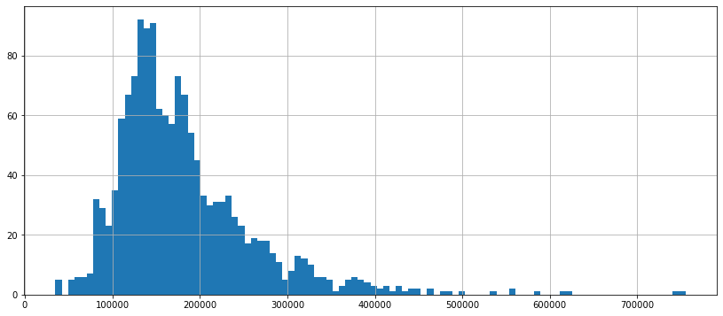

```python
# Viewing the histogram of the feature
df['SalePrice'].hist(bins=100, figsize=[14,6])
```

Here, we notice that the distribution is skewed. We shall apply a transformation to the variable to make the distribution normal.

#### Log Transformation of Predicted variable - SalePrice

```python
# Log Transofrmation of SalePrice
df['SalePrice'] = np.log(df.SalePrice)
```

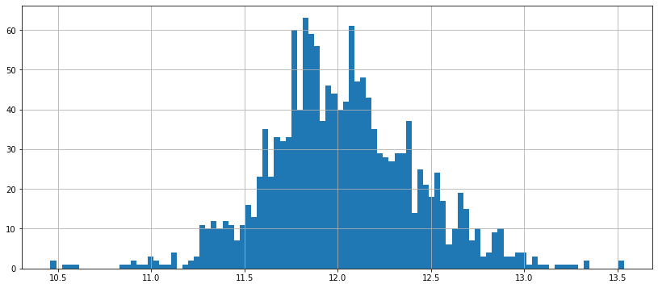

```python
# Viewing the histogram of the feature
df['SalePrice'].hist(bins=100, figsize=[14,6])
```

We notice that after we apply LOG transformation, the dataset has a normal distribution now.

#### Correlation Analysis

```python
# correlation matrix
cor = df.corr()
cor
```

|  | Id | MSSubClass | LotFrontage | LotArea | OverallQual | OverallCond | YearBuilt | YearRemodAdd | MasVnrArea | BsmtFinSF1 | BsmtFinSF2 | BsmtUnfSF | TotalBsmtSF | CentralAir | 1stFlrSF | 2ndFlrSF | LowQualFinSF | GrLivArea | BsmtFullBath | BsmtHalfBath | FullBath | HalfBath | BedroomAbvGr | KitchenAbvGr | TotRmsAbvGrd | Fireplaces | GarageYrBlt | GarageCars | GarageArea | … |
| --- | --- | --- | --- | --- | --- | --- | --- | --- | --- | --- | --- | --- | --- | --- | --- | --- | --- | --- | --- | --- | --- | --- | --- | --- | --- | --- | --- | --- | --- | --- |
| Id | 1.000000 | 0.011156 | -0.012497 | -0.033226 | -0.028365 | 0.012609 | 0.012713 | 0.021998 | -0.051071 | -0.005024 | -0.005968 | -0.007940 | -0.015415 | 0.009821 | 0.010496 | 0.005590 | -0.044230 | 0.008273 | 0.002289 | -0.020155 | 0.005587 | 0.006784 | 0.037719 | 0.002951 | 0.027239 | -0.019772 | 0.003243 | 0.016570 | 0.017634 | … |
| MSSubClass | 0.011156 | 1.000000 | -0.349116 | -0.139781 | 0.032628 | -0.059316 | -0.027850 | -0.040581 | 0.023573 | -0.069836 | -0.065649 | -0.140759 | -0.238518 | -0.101774 | -0.251758 | 0.307886 | 0.046474 | 0.074853 | 0.003491 | -0.002333 | 0.131608 | 0.177354 | -0.023438 | 0.281721 | 0.040380 | -0.045569 | -0.098664 | -0.040110 | -0.098672 | … |
| LotFrontage | -0.012497 | -0.349116 | 1.000000 | 0.281283 | 0.236891 | -0.056461 | -0.107427 | -0.087325 | 0.174146 | 0.199171 | 0.034498 | 0.138852 | 0.359606 | 0.055341 | 0.404099 | 0.070626 | 0.042211 | 0.359866 | 0.079531 | -0.011613 | 0.179058 | 0.037839 | 0.232143 | 0.002760 | 0.319389 | 0.208721 | -0.040960 | 0.264353 | 0.317925 | … |
| LotArea | -0.033226 | -0.139781 | 0.281283 | 1.000000 | 0.105806 | -0.005636 | -0.014228 | -0.013788 | 0.103321 | 0.214103 | 0.111170 | -0.002618 | 0.260833 | 0.049755 | 0.299475 | 0.050986 | 0.004779 | 0.263116 | 0.158155 | 0.048046 | 0.126031 | 0.014259 | 0.119690 | -0.017784 | 0.190015 | 0.271364 | 0.042198 | 0.154871 | 0.180403 | … |
| OverallQual | -0.028365 | 0.032628 | 0.236891 | 0.105806 | 1.000000 | -0.091932 | -0.572323 | -0.550684 | 0.407252 | 0.239666 | -0.059119 | 0.308159 | 0.537808 | 0.272038 | 0.476224 | 0.295493 | -0.030429 | 0.593007 | 0.111098 | -0.040150 | 0.550600 | 0.273458 | 0.101676 | -0.183882 | 0.427452 | 0.396765 | -0.437998 | 0.600671 | 0.562022 | … |
| OverallCond | 0.012609 | -0.059316 | -0.056461 | -0.005636 | -0.091932 | 1.000000 | 0.375983 | -0.073741 | -0.125694 | -0.046231 | 0.040229 | -0.136841 | -0.171098 | 0.118969 | -0.144203 | 0.028942 | 0.025494 | -0.079686 | -0.054942 | 0.117821 | -0.194149 | -0.060769 | 0.012980 | -0.087001 | -0.057583 | -0.023820 | 0.299203 | -0.185758 | -0.151521 | … |
| YearBuilt | 0.012713 | -0.027850 | -0.107427 | -0.014228 | -0.572323 | 0.375983 | 1.000000 | 0.592855 | -0.311600 | -0.249503 | 0.049107 | -0.149040 | -0.391452 | -0.381831 | -0.281986 | -0.010308 | 0.183784 | -0.199010 | -0.187599 | 0.038162 | -0.468271 | -0.242656 | 0.070651 | 0.174800 | -0.095589 | -0.147716 | 0.700098 | -0.537850 | -0.478954 | … |
| YearRemodAdd | 0.021998 | -0.040581 | -0.087325 | -0.013788 | -0.550684 | -0.073741 | 0.592855 | 1.000000 | -0.176529 | -0.128451 | 0.067759 | -0.181133 | -0.291066 | -0.298878 | -0.240379 | -0.140024 | 0.062419 | -0.287389 | -0.119470 | 0.012337 | -0.439046 | -0.183331 | 0.040581 | 0.149598 | -0.191740 | -0.112581 | 0.571369 | -0.420622 | -0.371600 | … |
| MasVnrArea | -0.051071 | 0.023573 | 0.174146 | 0.103321 | 0.407252 | -0.125694 | -0.311600 | -0.176529 | 1.000000 | 0.261256 | -0.071330 | 0.113862 | 0.360067 | 0.126409 | 0.339850 | 0.173800 | -0.068628 | 0.388052 | 0.083010 | 0.027403 | 0.272999 | 0.199108 | 0.102775 | -0.038450 | 0.279568 | 0.247015 | -0.209289 | 0.361945 | 0.370884 | … |
| BsmtFinSF1 | -0.005024 | -0.069836 | 0.199171 | 0.214103 | 0.239666 | -0.046231 | -0.249503 | -0.128451 | 0.261256 | 1.000000 | -0.050117 | -0.495251 | 0.522396 | 0.166468 | 0.445863 | -0.137079 | -0.064503 | 0.208171 | 0.649212 | 0.067418 | 0.058543 | 0.004262 | -0.107355 | -0.081007 | 0.044316 | 0.260011 | -0.119267 | 0.224054 | 0.296970 | … |
| BsmtFinSF2 | -0.005968 | -0.065649 | 0.034498 | 0.111170 | -0.059119 | 0.040229 | 0.049107 | 0.067759 | -0.071330 | -0.050117 | 1.000000 | -0.209294 | 0.104810 | 0.039936 | 0.097117 | -0.099260 | 0.014807 | -0.009640 | 0.158678 | 0.070948 | -0.076444 | -0.032148 | -0.015728 | -0.040751 | -0.035227 | 0.046921 | 0.094208 | -0.038264 | -0.018227 | … |
| BsmtUnfSF | -0.007940 | -0.140759 | 0.138852 | -0.002618 | 0.308159 | -0.136841 | -0.149040 | -0.181133 | 0.113862 | -0.495251 | -0.209294 | 1.000000 | 0.415360 | 0.020060 | 0.317987 | 0.004469 | 0.028167 | 0.240257 | -0.422900 | -0.095804 | 0.288886 | -0.041118 | 0.166643 | 0.030086 | 0.250647 | 0.051575 | -0.172350 | 0.214175 | 0.183303 | … |
| TotalBsmtSF | -0.015415 | -0.238518 | 0.359606 | 0.260833 | 0.537808 | -0.171098 | -0.391452 | -0.291066 | 0.360067 | 0.522396 | 0.104810 | 0.415360 | 1.000000 | 0.207958 | 0.819530 | -0.174512 | -0.033245 | 0.454868 | 0.307351 | -0.000315 | 0.323722 | -0.048804 | 0.050450 | -0.068901 | 0.285573 | 0.339519 | -0.262945 | 0.434585 | 0.486665 | … |
| CentralAir | 0.009821 | -0.101774 | 0.055341 | 0.049755 | 0.272038 | 0.118969 | -0.381831 | -0.298878 | 0.126409 | 0.166468 | 0.039936 | 0.020060 | 0.207958 | 1.000000 | 0.146953 | -0.011803 | -0.050149 | 0.093666 | 0.114603 | 0.040325 | 0.109326 | 0.134637 | 0.007872 | -0.246797 | 0.034509 | 0.186309 | -0.204135 | 0.233726 | 0.230741 | … |
| 1stFlrSF | 0.010496 | -0.251758 | 0.404099 | 0.299475 | 0.476224 | -0.144203 | -0.281986 | -0.240379 | 0.339850 | 0.445863 | 0.097117 | 0.317987 | 0.819530 | 0.146953 | 1.000000 | -0.202646 | -0.014241 | 0.566024 | 0.244671 | 0.001956 | 0.380637 | -0.119916 | 0.127401 | 0.068101 | 0.409516 | 0.410531 | -0.182240 | 0.439317 | 0.489782 | … |
| 2ndFlrSF | 0.005590 | 0.307886 | 0.070626 | 0.050986 | 0.295493 | 0.028942 | -0.010308 | -0.140024 | 0.173800 | -0.137079 | -0.099260 | 0.004469 | -0.174512 | -0.011803 | -0.202646 | 1.000000 | 0.063353 | 0.687501 | -0.169494 | -0.023855 | 0.421378 | 0.609707 | 0.502901 | 0.059306 | 0.616423 | 0.194561 | -0.052291 | 0.183926 | 0.138347 | … |
| LowQualFinSF | -0.044230 | 0.046474 | 0.042211 | 0.004779 | -0.030429 | 0.025494 | 0.183784 | 0.062419 | -0.068628 | -0.064503 | 0.014807 | 0.028167 | -0.033245 | -0.050149 | -0.014241 | 0.063353 | 1.000000 | 0.134683 | -0.047143 | -0.005842 | -0.000710 | -0.027080 | 0.105607 | 0.007522 | 0.131185 | -0.021272 | -0.007298 | -0.094480 | -0.067601 | … |
| GrLivArea | 0.008273 | 0.074853 | 0.359866 | 0.263116 | 0.593007 | -0.079686 | -0.199010 | -0.287389 | 0.388052 | 0.208171 | -0.009640 | 0.240257 | 0.454868 | 0.093666 | 0.566024 | 0.687501 | 0.134683 | 1.000000 | 0.034836 | -0.018918 | 0.630012 | 0.415772 | 0.521270 | 0.100063 | 0.825489 | 0.461679 | -0.178186 | 0.467247 | 0.468997 | … |
| BsmtFullBath | 0.002289 | 0.003491 | 0.079531 | 0.158155 | 0.111098 | -0.054942 | -0.187599 | -0.119470 | 0.083010 | 0.649212 | 0.158678 | -0.422900 | 0.307351 | 0.114603 | 0.244671 | -0.169494 | -0.047143 | 0.034836 | 1.000000 | -0.147871 | -0.064512 | -0.030905 | -0.150673 | -0.041503 | -0.053275 | 0.137928 | -0.105716 | 0.131881 | 0.179189 | … |
| BsmtHalfBath | -0.020155 | -0.002333 | -0.011613 | 0.048046 | -0.040150 | 0.117821 | 0.038162 | 0.012337 | 0.027403 | 0.067418 | 0.070948 | -0.095804 | -0.000315 | 0.040325 | 0.001956 | -0.023855 | -0.005842 | -0.018918 | -0.147871 | 1.000000 | -0.054536 | -0.012340 | 0.046519 | -0.037944 | -0.023836 | 0.028976 | 0.077945 | -0.020891 | -0.024536 | … |
| FullBath | 0.005587 | 0.131608 | 0.179058 | 0.126031 | 0.550600 | -0.194149 | -0.468271 | -0.439046 | 0.272999 | 0.058543 | -0.076444 | 0.288886 | 0.323722 | 0.109326 | 0.380637 | 0.421378 | -0.000710 | 0.630012 | -0.064512 | -0.054536 | 1.000000 | 0.136381 | 0.363252 | 0.133115 | 0.554784 | 0.243671 | -0.426511 | 0.469672 | 0.405656 | … |
| HalfBath | 0.006784 | 0.177354 | 0.037839 | 0.014259 | 0.273458 | -0.060769 | -0.242656 | -0.183331 | 0.199108 | 0.004262 | -0.032148 | -0.041118 | -0.048804 | 0.134637 | -0.119916 | 0.609707 | -0.027080 | 0.415772 | -0.030905 | -0.012340 | 0.136381 | 1.000000 | 0.226651 | -0.068263 | 0.343415 | 0.203649 | -0.158951 | 0.219178 | 0.163549 | … |
| BedroomAbvGr | 0.037719 | -0.023438 | 0.232143 | 0.119690 | 0.101676 | 0.012980 | 0.070651 | 0.040581 | 0.102775 | -0.107355 | -0.015728 | 0.166643 | 0.050450 | 0.007872 | 0.127401 | 0.502901 | 0.105607 | 0.521270 | -0.150673 | 0.046519 | 0.363252 | 0.226651 | 1.000000 | 0.198597 | 0.676620 | 0.107570 | 0.056782 | 0.086106 | 0.065253 | … |
| KitchenAbvGr | 0.002951 | 0.281721 | 0.002760 | -0.017784 | -0.183882 | -0.087001 | 0.174800 | 0.149598 | -0.038450 | -0.081007 | -0.040751 | 0.030086 | -0.068901 | -0.246797 | 0.068101 | 0.059306 | 0.007522 | 0.100063 | -0.041503 | -0.037944 | 0.133115 | -0.068263 | 0.198597 | 1.000000 | 0.256045 | -0.123936 | 0.066911 | -0.050634 | -0.064433 | … |
| TotRmsAbvGrd | 0.027239 | 0.040380 | 0.319389 | 0.190015 | 0.427452 | -0.057583 | -0.095589 | -0.191740 | 0.279568 | 0.044316 | -0.035227 | 0.250647 | 0.285573 | 0.034509 | 0.409516 | 0.616423 | 0.131185 | 0.825489 | -0.053275 | -0.023836 | 0.554784 | 0.343415 | 0.676620 | 0.256045 | 1.000000 | 0.326114 | -0.114855 | 0.362289 | 0.337822 | … |
| Fireplaces | -0.019772 | -0.045569 | 0.208721 | 0.271364 | 0.396765 | -0.023820 | -0.147716 | -0.112581 | 0.247015 | 0.260011 | 0.046921 | 0.051575 | 0.339519 | 0.186309 | 0.410531 | 0.194561 | -0.021272 | 0.461679 | 0.137928 | 0.028976 | 0.243671 | 0.203649 | 0.107570 | -0.123936 | 0.326114 | 1.000000 | 0.000926 | 0.300789 | 0.269141 | … |
| GarageYrBlt | 0.003243 | -0.098664 | -0.040960 | 0.042198 | -0.437998 | 0.299203 | 0.700098 | 0.571369 | -0.209289 | -0.119267 | 0.094208 | -0.172350 | -0.262945 | -0.204135 | -0.182240 | -0.052291 | -0.007298 | -0.178186 | -0.105716 | 0.077945 | -0.426511 | -0.158951 | 0.056782 | 0.066911 | -0.114855 | 0.000926 | 1.000000 | -0.327283 | -0.330489 | … |
| GarageCars | 0.016570 | -0.040110 | 0.264353 | 0.154871 | 0.600671 | -0.185758 | -0.537850 | -0.420622 | 0.361945 | 0.224054 | -0.038264 | 0.214175 | 0.434585 | 0.233726 | 0.439317 | 0.183926 | -0.094480 | 0.467247 | 0.131881 | -0.020891 | 0.469672 | 0.219178 | 0.086106 | -0.050634 | 0.362289 | 0.300789 | -0.327283 | 1.000000 | 0.882475 | … |
| GarageArea | 0.017634 | -0.098672 | 0.317925 | 0.180403 | 0.562022 | -0.151521 | -0.478954 | -0.371600 | 0.370884 | 0.296970 | -0.018227 | 0.183303 | 0.486665 | 0.230741 | 0.489782 | 0.138347 | -0.067601 | 0.468997 | 0.179189 | -0.024536 | 0.405656 | 0.163549 | 0.065253 | -0.064433 | 0.337822 | 0.269141 | -0.330489 | 0.882475 | 1.000000 | … |
| WoodDeckSF | -0.029643 | -0.012579 | 0.061329 | 0.171698 | 0.238923 | -0.003334 | -0.224880 | -0.205726 | 0.159991 | 0.204306 | 0.067898 | -0.005316 | 0.232019 | 0.145973 | 0.235459 | 0.092165 | -0.025444 | 0.247433 | 0.175315 | 0.040161 | 0.187703 | 0.108080 | 0.046854 | -0.090130 | 0.165984 | 0.200019 | -0.187961 | 0.226342 | 0.224666 | … |

[output cut: 231 more lines]

### Data Preparation

```python
# Viewing the shape of the data
df.shape
```

```
(1460, 261)
```

```python
# Separating the SalePrice Column
SalePrice = df.pop('SalePrice')
Id = df.pop('Id')
```

```python
# Viewing the head of the daya
df.head()
```

|  | MSSubClass | LotFrontage | LotArea | OverallQual | OverallCond | YearBuilt | YearRemodAdd | MasVnrArea | BsmtFinSF1 | BsmtFinSF2 | BsmtUnfSF | TotalBsmtSF | CentralAir | 1stFlrSF | 2ndFlrSF | LowQualFinSF | GrLivArea | BsmtFullBath | BsmtHalfBath | FullBath | HalfBath | BedroomAbvGr | KitchenAbvGr | TotRmsAbvGrd | Fireplaces | GarageYrBlt | GarageCars | GarageArea | WoodDeckSF | … |
| --- | --- | --- | --- | --- | --- | --- | --- | --- | --- | --- | --- | --- | --- | --- | --- | --- | --- | --- | --- | --- | --- | --- | --- | --- | --- | --- | --- | --- | --- | --- |
| 0 | 60 | 65.0 | 8450 | 7 | 5 | 7 | 7 | 196.0 | 706 | 0 | 150 | 856 | 1 | 856 | 854 | 0 | 1710 | 1 | 0 | 2 | 1 | 3 | 1 | 8 | 0 | 7.0 | 2 | 548 | 0 | … |
| 1 | 20 | 80.0 | 9600 | 6 | 8 | 34 | 34 | 0.0 | 978 | 0 | 284 | 1262 | 1 | 1262 | 0 | 0 | 1262 | 0 | 1 | 2 | 0 | 3 | 1 | 6 | 1 | 34.0 | 2 | 460 | 298 | … |
| 2 | 60 | 68.0 | 11250 | 7 | 5 | 9 | 8 | 162.0 | 486 | 0 | 434 | 920 | 1 | 920 | 866 | 0 | 1786 | 1 | 0 | 2 | 1 | 3 | 1 | 6 | 1 | 9.0 | 2 | 608 | 0 | … |
| 3 | 70 | 60.0 | 9550 | 7 | 5 | 95 | 40 | 0.0 | 216 | 0 | 540 | 756 | 1 | 961 | 756 | 0 | 1717 | 1 | 0 | 1 | 0 | 3 | 1 | 7 | 1 | 12.0 | 3 | 642 | 0 | … |
| 4 | 60 | 84.0 | 14260 | 8 | 5 | 10 | 10 | 350.0 | 655 | 0 | 490 | 1145 | 1 | 1145 | 1053 | 0 | 2198 | 1 | 0 | 2 | 1 | 4 | 1 | 9 | 1 | 10.0 | 3 | 836 | 192 | … |

```python
# Splitting the dataset into dependent and independent features (X and y)
X = df
y = SalePrice
```

#### Feature Scaling

```python
# scaling the features
from sklearn.preprocessing import scale

# Scaling the predictor features
cols = X.columns
X = pd.DataFrame(scale(X))
X.columns = cols
X.columns
```

```
Index(['MSSubClass', 'LotFrontage', 'LotArea', 'OverallQual', 'OverallCond',
       'YearBuilt', 'YearRemodAdd', 'MasVnrArea', 'BsmtFinSF1', 'BsmtFinSF2',
       ...
       'SaleType_ConLI', 'SaleType_ConLw', 'SaleType_New', 'SaleType_Oth',
       'SaleType_WD', 'SaleCondition_AdjLand', 'SaleCondition_Alloca',
       'SaleCondition_Family', 'SaleCondition_Normal',
       'SaleCondition_Partial'],
      dtype='object', length=259)
```

```python
# split into train and test
from sklearn.model_selection import train_test_split
X_train, X_test, y_train, y_test = train_test_split(X, y, train_size=0.7, test_size = 0.3, random_state=100)
```

## Ridge and Lasso Regression

Let us now predict the Sale Price of the houses by performing ridge and lasso regression.

## Ridge Regression

```python
# importing required packages
from sklearn import linear_model
from sklearn import model_selection
from sklearn.model_selection import GridSearchCV
```

```python
# Resetting the index
df = df.reset_index()
```

```python
# Count of missing values column-wise
df.isna().sum()
```

```
index                        0
MSSubClass                   0
LotFrontage                  0
LotArea                      0
OverallQual                  0
OverallCond                  0
YearBuilt                    0
YearRemodAdd                 0
MasVnrArea                   0
BsmtFinSF1                   0
BsmtFinSF2                   0
BsmtUnfSF                    0
TotalBsmtSF                  0
CentralAir                   0
1stFlrSF                     0
2ndFlrSF                     0
LowQualFinSF                 0
GrLivArea                    0
BsmtFullBath                 0
BsmtHalfBath                 0
FullBath                     0
HalfBath                     0
BedroomAbvGr                 0
KitchenAbvGr                 0
TotRmsAbvGrd                 0
Fireplaces                   0
GarageYrBlt                  0
GarageCars                   0
GarageArea                   0
WoodDeckSF                   0
OpenPorchSF                  0
EnclosedPorch                0
3SsnPorch                    0
ScreenPorch                  0
PoolArea                     0
MiscVal                      0
MoSold                       0
YrSold                       0
MSZoning_FV                  0
MSZoning_RH                  0
```

[output cut: 206 more lines]

```
MiscFeature_TenC             0
SaleType_CWD                 0
SaleType_Con                 0
SaleType_ConLD               0
SaleType_ConLI               0
SaleType_ConLw               0
SaleType_New                 0
SaleType_Oth                 0
SaleType_WD                  0
SaleCondition_AdjLand        0
SaleCondition_Alloca         0
SaleCondition_Family         0
SaleCondition_Normal         0
SaleCondition_Partial        0
dtype: int64
```

```python
# List of alphas to tune
params = {'alpha': [0.0001, 0.001, 0.01, 0.05, 0.1, 0.2, 0.3, 0.4, 0.5, 0.6, 0.7, 0.8, 0.9, 1.0, 2.0, 3.0, 4.0, 5.0, 6.0,\
                    7.0, 8.0, 9.0, 10.0, 20, 50, 100, 500, 1000 ]}

# Initializing Ridge() object
ridge = linear_model.Ridge()

# Cross Validation using Grid Search
folds = 10
model_cv = GridSearchCV(estimator = ridge, param_grid = params, scoring= 'neg_mean_absolute_error', \
                        cv = folds, return_train_score=True, verbose = 1)

# Fitting the model
model_cv.fit(X_train, y_train)
```

```
Fitting 10 folds for each of 28 candidates, totalling 280 fits
```

```
[Parallel(n_jobs=1)]: Using backend SequentialBackend with 1 concurrent workers.
[Parallel(n_jobs=1)]: Done 280 out of 280 | elapsed:    5.0s finished
```

```
GridSearchCV(cv=10, error_score=nan,
             estimator=Ridge(alpha=1.0, copy_X=True, fit_intercept=True,
                             max_iter=None, normalize=False, random_state=None,
                             solver='auto', tol=0.001),
             iid='deprecated', n_jobs=None,
             param_grid={'alpha': [0.0001, 0.001, 0.01, 0.05, 0.1, 0.2, 0.3,
                                   0.4, 0.5, 0.6, 0.7, 0.8, 0.9, 1.0, 2.0, 3.0,
                                   4.0, 5.0, 6.0, 7.0, 8.0, 9.0, 10.0, 20, 50,
                                   100, 500, 1000]},
             pre_dispatch='2*n_jobs', refit=True, return_train_score=True,
             scoring='neg_mean_absolute_error', verbose=1)
```

```python
# Making a dataframe of the results
cv_results = pd.DataFrame(model_cv.cv_results_)
cv_results = cv_results[cv_results['param_alpha']<=200]
cv_results.head()
```

|  | mean_fit_time | std_fit_time | mean_score_time | std_score_time | param_alpha | params | split0_test_score | split1_test_score | split2_test_score | split3_test_score | split4_test_score | split5_test_score | split6_test_score | split7_test_score | split8_test_score | split9_test_score | mean_test_score | std_test_score | rank_test_score | split0_train_score | split1_train_score | split2_train_score | split3_train_score | split4_train_score | split5_train_score | split6_train_score | split7_train_score | split8_train_score | split9_train_score | … |
| --- | --- | --- | --- | --- | --- | --- | --- | --- | --- | --- | --- | --- | --- | --- | --- | --- | --- | --- | --- | --- | --- | --- | --- | --- | --- | --- | --- | --- | --- | --- |
| 0 | 0.011203 | 0.003917 | 0.003197 | 0.003915 | 0.0001 | {'alpha': 0.0001} | -0.094798 | -0.079902 | -0.086081 | -0.108780 | -0.078949 | -0.109290 | -0.091833 | -0.076853 | -0.085199 | -0.084347 | -0.089603 | 0.011031 | 26 | -0.056096 | -0.057326 | -0.056426 | -0.056807 | -0.057245 | -0.056715 | -0.056308 | -0.058433 | -0.057380 | -0.056289 | … |
| 1 | 0.012799 | 0.003919 | 0.002400 | 0.003666 | 0.001 | {'alpha': 0.001} | -0.094775 | -0.079902 | -0.086079 | -0.108780 | -0.078949 | -0.109287 | -0.091832 | -0.076850 | -0.085198 | -0.084343 | -0.089600 | 0.011030 | 25 | -0.056097 | -0.057326 | -0.056426 | -0.056807 | -0.057246 | -0.056715 | -0.056308 | -0.058433 | -0.057380 | -0.056289 | … |
| 2 | 0.010402 | 0.003666 | 0.002400 | 0.003666 | 0.01 | {'alpha': 0.01} | -0.094552 | -0.079901 | -0.086067 | -0.108779 | -0.078950 | -0.109257 | -0.091820 | -0.076822 | -0.085194 | -0.084303 | -0.089565 | 0.011020 | 24 | -0.056105 | -0.057328 | -0.056427 | -0.056807 | -0.057248 | -0.056717 | -0.056314 | -0.058437 | -0.057381 | -0.056294 | … |
| 3 | 0.012800 | 0.003919 | 0.001600 | 0.003200 | 0.05 | {'alpha': 0.05} | -0.093773 | -0.079891 | -0.086014 | -0.108776 | -0.078948 | -0.109135 | -0.091774 | -0.076698 | -0.085172 | -0.084160 | -0.089434 | 0.010988 | 23 | -0.056135 | -0.057334 | -0.056430 | -0.056808 | -0.057255 | -0.056724 | -0.056335 | -0.058451 | -0.057385 | -0.056314 | … |
| 4 | 0.012000 | 0.004000 | 0.001600 | 0.003200 | 0.1 | {'alpha': 0.1} | -0.093099 | -0.079878 | -0.085954 | -0.108770 | -0.078936 | -0.109001 | -0.091732 | -0.076552 | -0.085142 | -0.084035 | -0.089310 | 0.010966 | 22 | -0.056161 | -0.057339 | -0.056436 | -0.056809 | -0.057261 | -0.056729 | -0.056355 | -0.058468 | -0.057387 | -0.056332 | … |

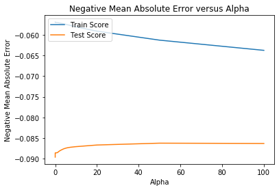

```python
# plotting mean test and train scoes with alpha
cv_results['param_alpha'] = cv_results['param_alpha'].astype('int32')

# Plotting the Negative Mean absolute error versus Alpha
plt.plot(cv_results['param_alpha'], cv_results['mean_train_score'])
plt.plot(cv_results['param_alpha'], cv_results['mean_test_score'])
plt.xlabel('Alpha')
plt.ylabel('Negative Mean Absolute Error')
plt.title("Negative Mean Absolute Error versus Alpha")
plt.legend(['Train Score', 'Test Score'], loc='upper left')
plt.show()
```

```python
alpha = 50
ridge = linear_model.Ridge(alpha=alpha)

ridge.fit(X_train, y_train)
ridge.coef_
```

```
array([-9.02729447e-03,  5.66876401e-03,  2.52268069e-02,  5.59875708e-02,
        3.73918913e-02, -3.46201323e-02, -2.37427991e-02,  2.85060570e-03,
        2.57850319e-02,  7.53334692e-03,  6.20886949e-03,  3.58310493e-02,
        1.66884294e-02,  4.21446329e-02,  3.51538466e-02, -9.13037905e-04,
        6.01237615e-02,  1.45050820e-02, -1.15520493e-03,  1.31723602e-02,
        8.85847994e-03,  8.06643852e-03, -1.52611189e-02,  1.24729760e-02,
        4.44628079e-03, -6.12923653e-04,  1.64010837e-02,  1.95950895e-02,
        1.13228988e-02,  4.83559358e-03,  3.95866477e-03,  4.42165410e-03,
        8.07058831e-03,  2.80807003e-03,  1.48208088e-03,  1.54769602e-04,
        3.22440123e-03,  1.76392729e-02,  9.86461842e-03,  3.72103921e-02,
        2.31682595e-02,  6.51854497e-03,  3.37208389e-03,  7.66662467e-03,
        2.25265317e-03, -2.29620459e-03,  1.21489146e-03,  2.77194432e-03,
       -1.22864234e-03,  6.15493349e-03, -1.96120807e-03,  7.73665237e-03,
       -7.44407522e-03, -1.67471110e-03, -3.36557096e-03,  3.29187428e-03,
       -1.25695861e-02, -4.43450946e-04, -7.57243217e-03,  3.94551734e-03,
        8.21450788e-03, -1.31142262e-03,  2.35577195e-02, -1.45737772e-02,
       -2.82756391e-03, -1.14469535e-02, -1.87142886e-02, -5.34973649e-03,
       -1.36922518e-03, -2.31320515e-04, -4.39642438e-03,  7.12438602e-03,
        1.48047418e-02, -5.91281429e-03,  6.04172560e-03, -4.55076332e-03,
        1.17552560e-03,  1.48985477e-02,  1.44417066e-02, -3.48322311e-04,
        5.96897127e-03,  4.58034209e-03,  2.25179533e-02,  4.20993512e-03,
        3.47722108e-03, -3.89680563e-03,  5.69315900e-03,  2.31542470e-04,
        4.41482588e-03,  2.45842985e-03,  7.24790725e-03,  6.42560162e-03,
       -5.13577075e-02, -9.28642412e-03, -5.76370809e-04,  5.09287933e-03,
       -2.67885854e-03, -1.08832851e-03, -9.38833361e-03, -3.15102134e-03,
        7.82395083e-04, -1.39224336e-02, -3.58325674e-03, -2.15310302e-05,
       -5.32193822e-04, -3.37701615e-03, -3.22417507e-03, -6.35914118e-03,
       -1.02167884e-03, -3.81068758e-03,  4.56586646e-03,  1.27930685e-02,
        1.29739466e-02,  8.60675521e-03,  6.73938469e-03,  3.88706291e-03,
        1.50382789e-02,  6.57071473e-04,  1.17329406e-02,  3.31139087e-04,
       -8.23047266e-03,  1.56699603e-02, -1.33851639e-04, -4.17825468e-04,
        7.55727495e-04,  1.69416562e-03,  5.28014060e-03,  1.16398510e-03,
        2.88869902e-03,  3.06551503e-03,  1.23380618e-02, -4.95671102e-03,
        4.23624501e-03,  1.91314413e-04,  8.38249574e-04, -2.41721982e-03,
       -1.33851639e-04,  9.59830396e-03,  2.24823321e-03,  1.30593082e-04,
        5.14330307e-03,  0.00000000e+00,  2.00925909e-03, -1.94241504e-03,
        1.14755415e-04,  6.54528551e-03,  4.65640093e-03, -4.38993707e-03,
        2.06075577e-03, -8.59742872e-04,  2.84932602e-03, -4.22801789e-03,
        1.84176170e-03, -3.59872416e-03, -4.78871354e-03, -4.09575230e-03,
        0.00000000e+00,  2.07159539e-03,  6.79938720e-03,  1.25270531e-02,
```

[output cut: 10 more lines]

```
       -5.19171152e-03, -2.15716008e-02, -1.79158762e-02, -8.96183694e-03,
        2.79187354e-03,  5.55410320e-03, -2.74157582e-03, -9.24239501e-03,
        1.47539306e-02, -1.57533310e-03,  6.00297384e-03, -8.59623406e-03,
       -3.33594319e-03,  3.93571782e-03,  6.21876179e-03, -2.55601204e-03,
        2.86883731e-03,  1.05584315e-03, -4.00003074e-03, -1.55082027e-03,
       -1.55082027e-03, -2.95949111e-03, -3.68889457e-03, -9.89656301e-03,
        5.31598850e-03, -1.55082027e-03, -1.31457386e-03, -3.03534495e-04,
       -4.63644907e-03, -2.11329219e-03, -1.55082027e-03,  4.12997252e-03,
       -2.80106778e-03,  5.21667358e-03,  6.68181558e-03,  3.48960839e-03,
       -9.51439469e-02,  5.33192785e-03, -9.19224251e-03,  6.06208077e-04,
        1.86179081e-03, -1.42327515e-03,  1.62545269e-03, -5.54318166e-04,
       -6.20011174e-04,  9.88751378e-32,  4.71935963e-03,  3.87348393e-03,
        1.73414190e-02,  2.03867210e-04,  2.04787178e-03,  1.43617631e-02,
        2.53982979e-03,  3.92711287e-03,  3.97258710e-03,  5.18031661e-03,
        3.22837448e-03,  1.93268211e-02,  1.42043083e-02])
```